# 3. Variable-wise comparison between Purchased and Aprraised cars

Sumit Kumar Kar

1/14/2023

In this file, I will do side by side plot of the variables common to the appraised and purchased cars. I will also do some additional exploration for these variables to make some conclusions that will be summarized in the final report.

# Side-by-side plots of each variable

## Model year

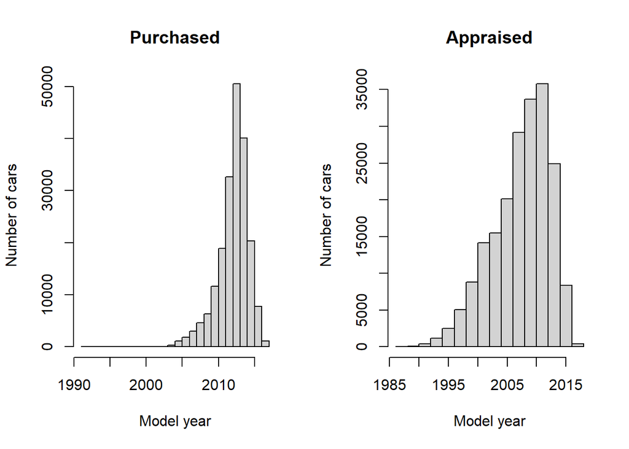

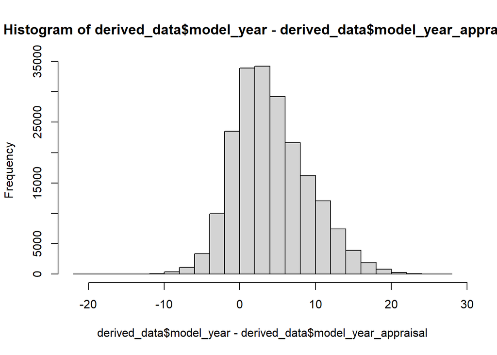

```r
hist(derived_data$model_year-derived_data$model_year_appraisal)
```

```r
summary(derived_data$model_year-derived_data$model_year_appraisal)
```

```
##    Min. 1st Qu.  Median    Mean 3rd Qu.    Max.
## -21.000   1.000   4.000   4.715   8.000  27.000
```

```r
sum(derived_data$model_year<derived_data$model_year_appraisal+4)/200000*100
```

```
## [1] 44.9475
```

The above results show that Model year of a person’s purchased car can be between 21 years older to 27 years younger than the appraised car. But 75% of the people purchase cars at least 1 year younger than the appraised car and 50% of the people purchase car at least 4 years younger than the appraised car.

## Mileage

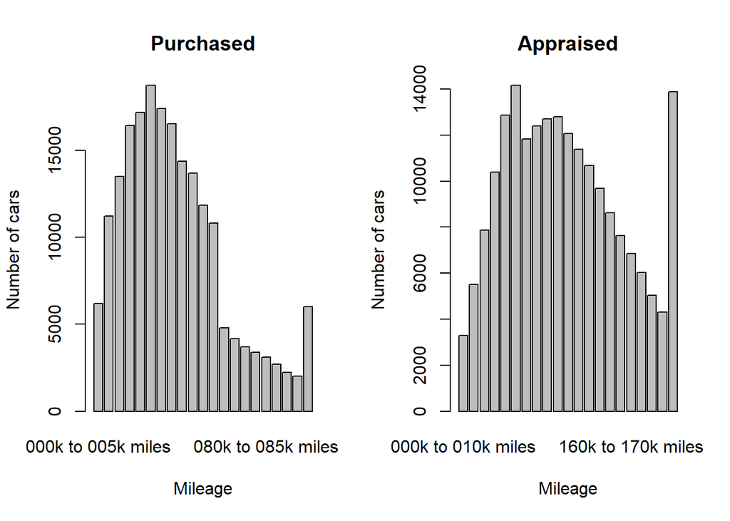

## Make

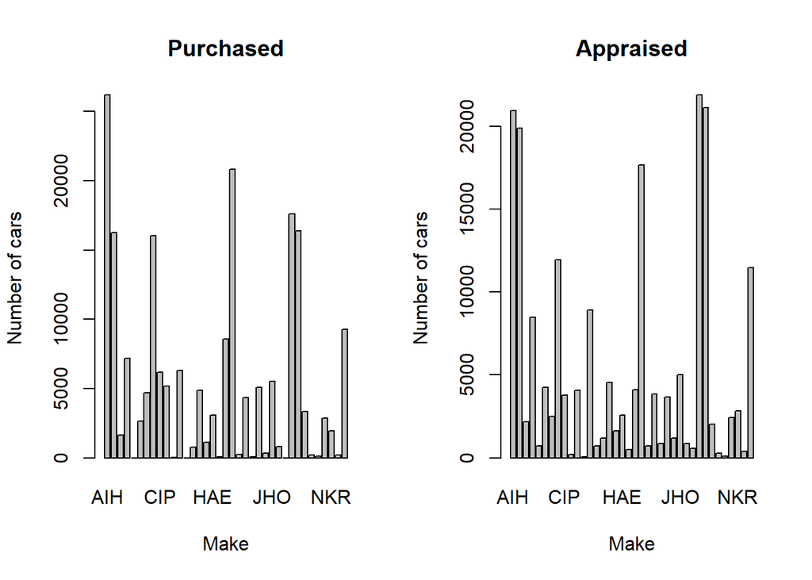

```r
sum(derived_data$make == derived_data$make_appraisal)/200000*100
```

```
## [1] 18.0895
```

```r
sum(derived_data$make != derived_data$make_appraisal)/200000*100
```

```
## [1] 81.9105
```

This shows that 18% people purchase a car with same make as the appraised car.

## Model

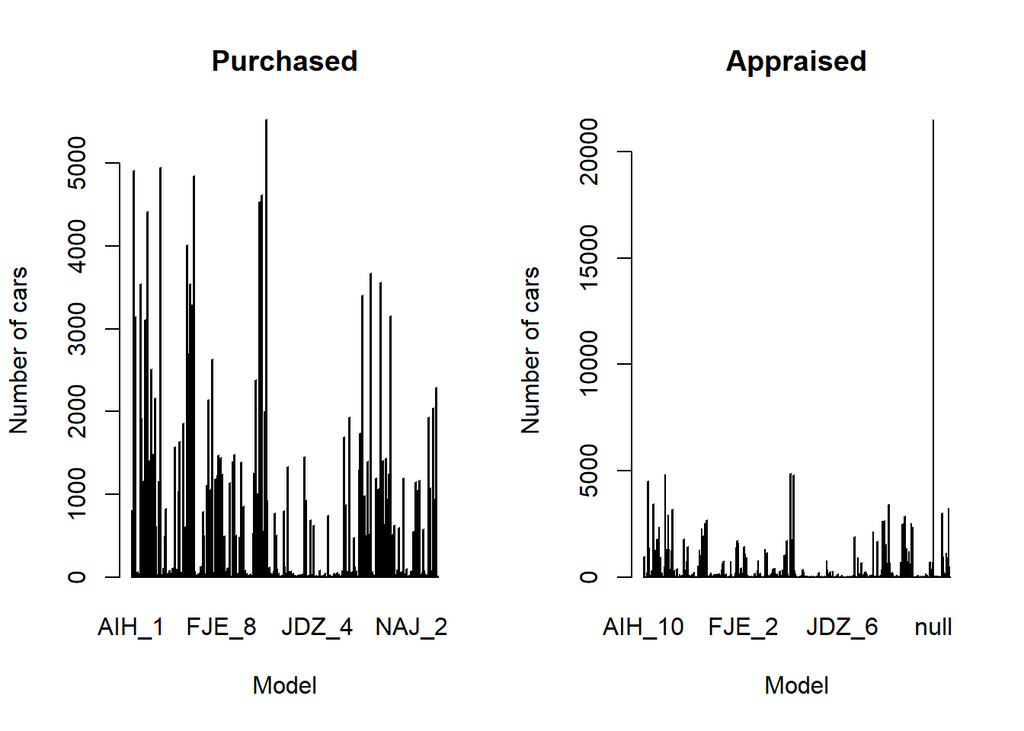

```r
sum(derived_data$model == derived_data$model_appraisal)/200000*100
```

```
## [1] 6.266
```

```r
sum(derived_data$model != derived_data$model_appraisal)/200000*100
```

```
## [1] 93.734
```

```r
sum(derived_data$model == derived_data$model_appraisal & derived_data$make == derived_data$make_appraisal)/200000*100
```

```
## [1] 6.266
```

This shows that 6.27% people stick to the same model too.

## Trim description

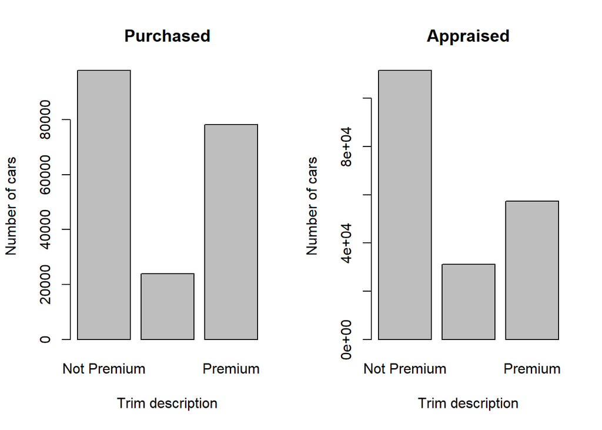

```r
sum(derived_data$trim_descrip == derived_data$trim_descrip_appraisal & derived_data$trim_descrip_appraisal != "null" & derived_data$trim_descrip != "null")/200000*100
```

```
## [1] 43.8995
```

```r
tally(trim_descrip ~ trim_descrip_appraisal, data = derived_data)/200000*100
```

```
##              trim_descrip_appraisal
## trim_descrip  Not Premium    null Premium
##   Not Premium     30.5180  6.8405 11.6015
##   null             5.3560  2.8710  3.6935
##   Premium         19.9095  5.8285 13.3815
```

This shows that not only 44% people stick to the same trim description, but also 20% people trade in a non-premium car to purchase a premium car. But most surprisingly, 12% people actually trade in a premium car to purchase a non-premium car.

## Body

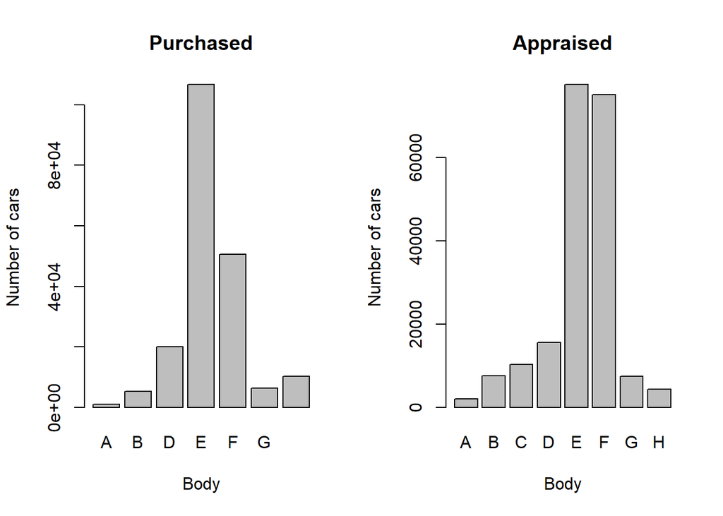

```r
sum(derived_data$body == derived_data$body_appraisal & derived_data$body_appraisal != "null" & derived_data$body != "null")/200000*100
```

```
## [1] 45.3895
```

This shows that 45% people purchase a car with same body as the appraised car.

## Color

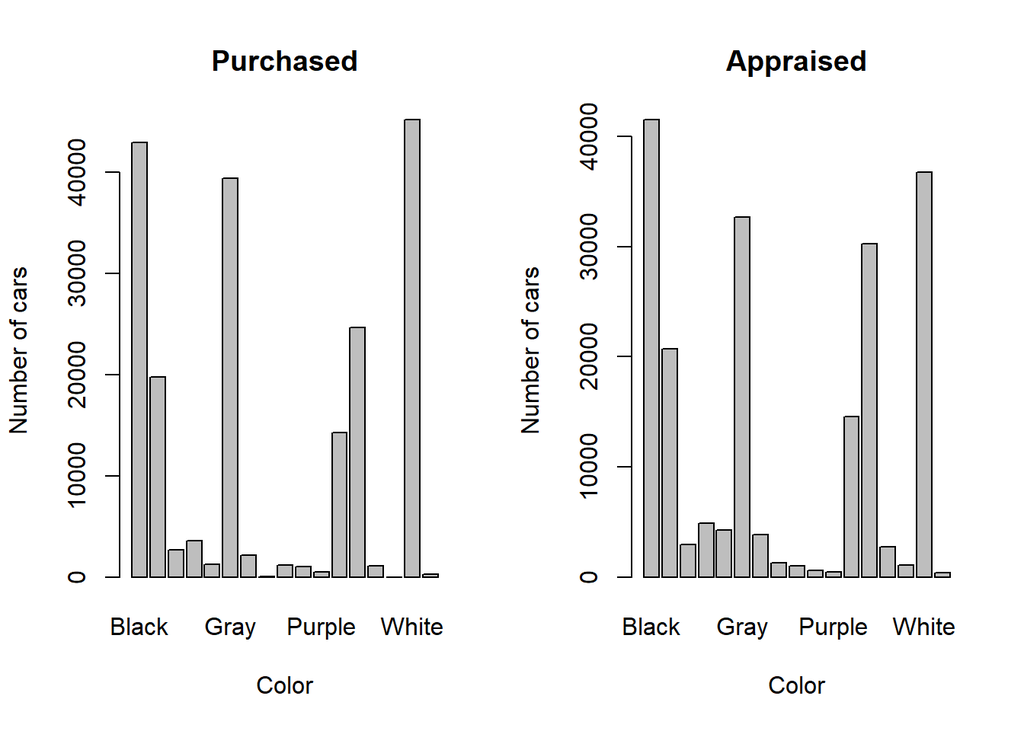

```r
sum(derived_data$color == derived_data$color_appraisal & derived_data$color_appraisal != "null" & derived_data$color != "null")/200000*100
```

```
## [1] 18.709
```

```r
a <- sum(derived_data$color == derived_data$color_appraisal & (derived_data$color == "Black" |derived_data$color == "Gray" |derived_data$color == "Silver" |derived_data$color == "White" ))
b <- sum(derived_data$color != derived_data$color_appraisal & (derived_data$color == "Black" |derived_data$color == "Gray" |derived_data$color == "Silver" |derived_data$color == "White" ))
a/(a+b)*100
```

```
## [1] 21.54314
```

```
## X
##    White    Black     Gray   Silver     Blue      Red Burgundy    Brown
##  22.5990  21.4680  19.6975  12.3270   9.8725   7.1200   1.8045   1.3370
##    Green     Gold   Orange      Tan    Pearl   Purple   Yellow     null
##   1.0665   0.6390   0.5885   0.5545   0.5225   0.2485   0.1365   0.0165
##  Unknown
##   0.0020
```

```
## X
##    Black    White     Gray   Silver     Blue      Red Burgundy     Gold
##  20.7670  18.3690  16.3430  15.1130  10.3535   7.2730   2.4565   2.1235
##    Green    Brown      Tan     null  Unknown   Orange    Pearl   Purple
##   1.9075   1.4580   1.3835   0.6590   0.5495   0.4930   0.3115   0.2305
##   Yellow
##   0.2090
```

This shows thta be it a purchased or an appraised car, the most popular colors are white and black, followed by gray, and silver respectively. In fact, 76% people purchase a car out of these colors and 70% appraise a car out of these 4 colors. Also, 19% people purchase the same color.

## Engine

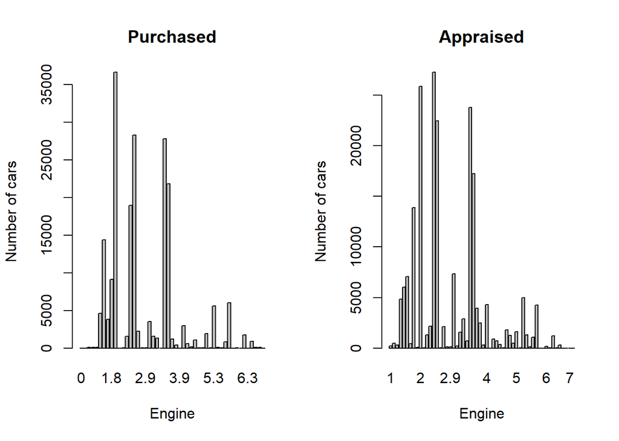

```r
sum(derived_data$engine == derived_data$engine_appraisal & derived_data$engine_appraisal != "null" & derived_data$engine != "null")/200000*100
```

```
## [1] 15.0395
```

This shows that 15% people purchase the same engine type.

## Cylinders

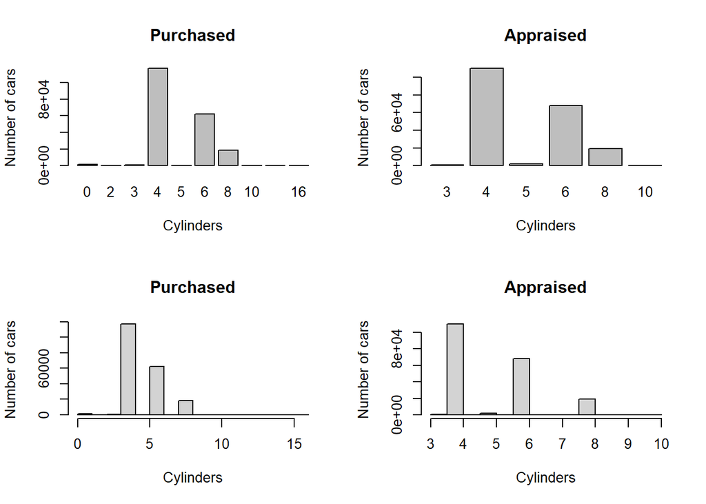

```r
sum(derived_data$cylinders == derived_data$cylinders_appraisal & derived_data$cylinders_appraisal != "null" & derived_data$cylinders != "null")/200000*100
```

```
## [1] 53.5395
```

```r
derived_data_c = subset(derived_data, derived_data$cylinders_appraisal != "null" & derived_data$cylinders != "null")
```

```
## X
##       4       6       8       0       3       5       2      16      12      10
## 58.5260 31.0855  9.3140  0.6990  0.1965  0.1195  0.0475  0.0065  0.0040  0.0015
```

```
## X
##       4       6       8       5       3      10
## 55.0600 34.0490  9.6375  0.8955  0.3535  0.0045
```

This shows that 53% people purchase the same number of cylinders. Be it a purchased or an appraised car, the most popular number of cylinders is 4, followed by 6 and 8 respectively. In fact, 99% of the (both purchased and appraised) cars have one of these 3 options and more than 55% cars have 4 cylinders.

## City mpg

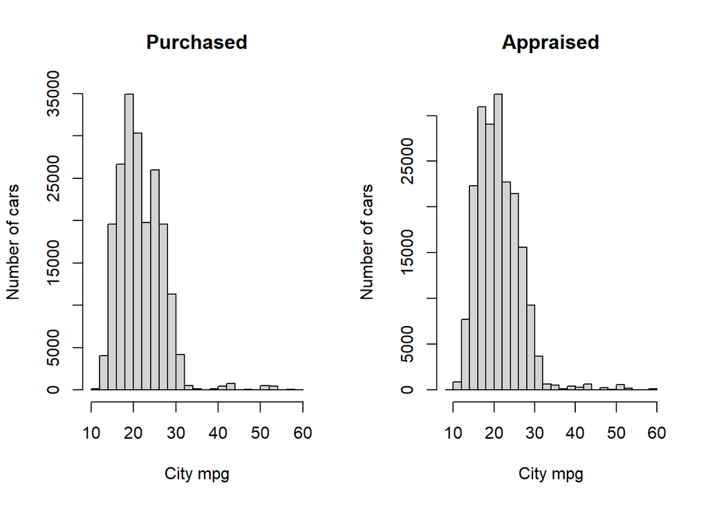

```r
sum(derived_data$mpg_city < derived_data$mpg_city_appraisal & is.na(derived_data$mpg_city) == FALSE & is.na(derived_data$mpg_city_appraisal) == FALSE)/200000*100
```

```
## [1] 41.656
```

```r
sum(derived_data$mpg_city > derived_data$mpg_city_appraisal & is.na(derived_data$mpg_city) == FALSE & is.na(derived_data$mpg_city_appraisal) == FALSE)/200000*100
```

```
## [1] 49.884
```

```r
t.test(derived_data$mpg_city, derived_data$mpg_city_appraisal, paired = TRUE)
```

```
##
##  Paired t-test
##
## data:  derived_data$mpg_city and derived_data$mpg_city_appraisal
## t = 32.683, df = 199408, p-value < 2.2e-16
## alternative hypothesis: true difference in means is not equal to 0
## 95 percent confidence interval:
##  0.4592936 0.5178940
## sample estimates:
## mean of the differences
##               0.4885938
```

This shows that there is a significant difference between the city mpg of appraised and purchased cars.

## Highway mpg

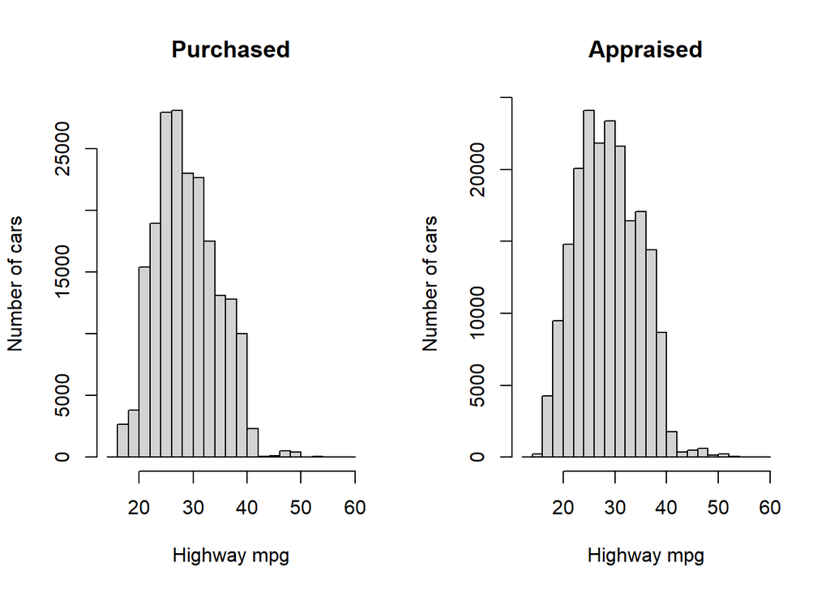

```r
sum(derived_data$mpg_highway < derived_data$mpg_highway_appraisal & is.na(derived_data$mpg_highway) == FALSE & is.na(derived_data$mpg_highway_appraisal) == FALSE)/200000*100
```

```
## [1] 45.568
```

```r
sum(derived_data$mpg_highway > derived_data$mpg_highway_appraisal & is.na(derived_data$mpg_highway) == FALSE & is.na(derived_data$mpg_highway_appraisal) == FALSE)/200000*100
```

```
## [1] 47.542
```

```r
t.test(derived_data$mpg_highway, derived_data$mpg_highway_appraisal, paired = TRUE)
```

```
##
##  Paired t-test
##
## data:  derived_data$mpg_highway and derived_data$mpg_highway_appraisal
## t = 9.8152, df = 199409, p-value < 2.2e-16
## alternative hypothesis: true difference in means is not equal to 0
## 95 percent confidence interval:
##  0.1270803 0.1904965
## sample estimates:
## mean of the differences
##               0.1587884
```

This shows that there is a significant difference between the highwatympg of appraised and purchased cars.

## Horsepower

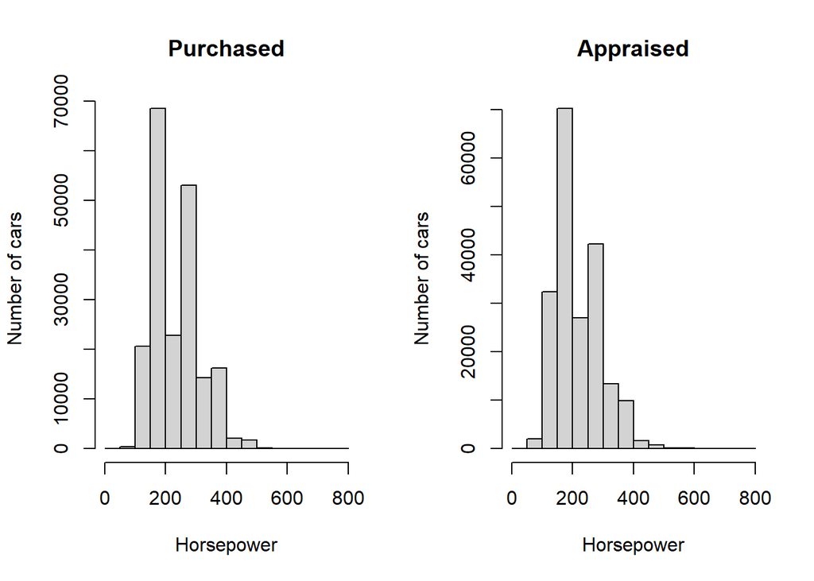

```r
sum(derived_data$horsepower < derived_data$horsepower_appraisal & is.na(derived_data$horsepower) == FALSE & is.na(derived_data$horsepower_appraisal) == FALSE)/200000*100
```

```
## [1] 37.896
```

```r
sum(derived_data$horsepower > derived_data$horsepower_appraisal & is.na(derived_data$horsepower) == FALSE & is.na(derived_data$horsepower_appraisal) == FALSE)/200000*100
```

```
## [1] 58.98
```

```r
t.test(derived_data$horsepower, derived_data$horsepower_appraisal, paired = TRUE)
```

```
##
##  Paired t-test
##
## data:  derived_data$horsepower and derived_data$horsepower_appraisal
## t = 90.79, df = 2e+05, p-value < 2.2e-16
## alternative hypothesis: true difference in means is not equal to 0
## 95 percent confidence interval:
##  16.85450 17.59827
## sample estimates:
## mean of the differences
##                17.22639
```

This shows that there is a significant difference between the horsepower of appraised and purchased cars.

## Fuel capacity

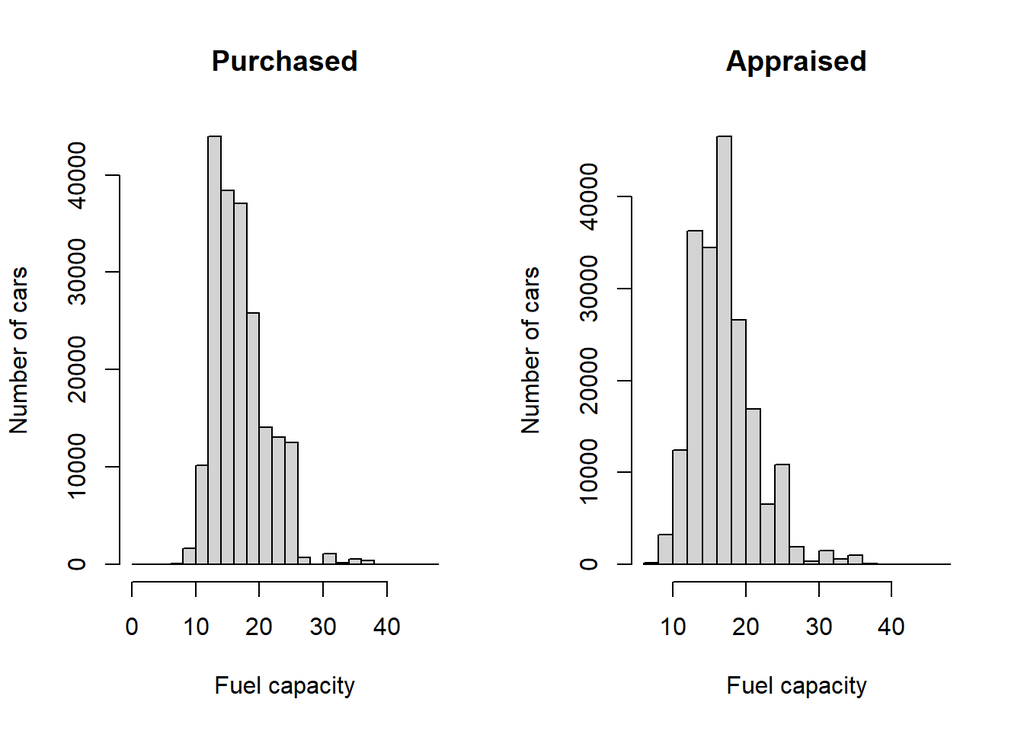

```r
sum(derived_data$fuel_capacity < derived_data$fuel_capacity_appraisal & is.na(derived_data$fuel_capacity) == FALSE & is.na(derived_data$fuel_capacity_appraisal) == FALSE)/200000*100
```

```
## [1] 43.7455
```

```r
sum(derived_data$fuel_capacity > derived_data$fuel_capacity_appraisal & is.na(derived_data$fuel_capacity) == FALSE & is.na(derived_data$fuel_capacity_appraisal) == FALSE)/200000*100
```

```
## [1] 42.9745
```

```r
t.test(derived_data$fuel_capacity, derived_data$fuel_capacity_appraisal, paired = TRUE)
```

```
##
##  Paired t-test
##
## data:  derived_data$fuel_capacity and derived_data$fuel_capacity_appraisal
## t = 1.1826, df = 199683, p-value = 0.237
## alternative hypothesis: true difference in means is not equal to 0
## 95 percent confidence interval:
##  -0.008980268  0.036303439
## sample estimates:
## mean of the differences
##              0.01366159
```

This shows that there is no (statistically) significant difference in the fuel capacity of the purchased car and appraised car of a person.